# Hate Crime Analysis

#### DSC 540

#### Project Milestone 5

#### 06/01/2024

### *Project Milestone 2*

```python
# import required libraries

import pandas as pd
import numpy as np
import matplotlib.pyplot as plt
import seaborn as sns
from scipy import stats
```

```python
#read chosen CSV file

hate_crime_stats = pd.read_csv("hate_crime.csv")
hate_crime_stats.head()
```

|  | INCIDENT_ID | DATA_YEAR | ORI | PUB_AGENCY_NAME | PUB_AGENCY_UNIT | AGENCY_TYPE_NAME | STATE_ABBR | STATE_NAME | DIVISION_NAME | REGION_NAME | ... | OFFENDER_RACE | OFFENDER_ETHNICITY | VICTIM_COUNT | OFFENSE_NAME | TOTAL_INDIVIDUAL_VICTIMS | LOCATION_NAME | BIAS_DESC | VICTIM_TYPES | MULTIPLE_OFFENSE | MULTIPLE_BIAS |
| --- | --- | --- | --- | --- | --- | --- | --- | --- | --- | --- | --- | --- | --- | --- | --- | --- | --- | --- | --- | --- | --- |
| 0 | 3015 | 1991 | AR0040200 | Rogers | NaN | City | AR | Arkansas | West South Central | South | ... | White | NaN | 1 | Intimidation | 1.0 | Highway/Road/Alley/Street/Sidewalk | Anti-Black or African American | Individual | S | S |
| 1 | 3016 | 1991 | AR0290100 | Hope | NaN | City | AR | Arkansas | West South Central | South | ... | Black or African American | NaN | 1 | Simple Assault | 1.0 | Highway/Road/Alley/Street/Sidewalk | Anti-White | Individual | S | S |
| 2 | 43 | 1991 | AR0350100 | Pine Bluff | NaN | City | AR | Arkansas | West South Central | South | ... | Black or African American | NaN | 1 | Aggravated Assault | 1.0 | Residence/Home | Anti-Black or African American | Individual | S | S |
| 3 | 44 | 1991 | AR0350100 | Pine Bluff | NaN | City | AR | Arkansas | West South Central | South | ... | Black or African American | NaN | 2 | Aggravated Assault;Destruction/Damage/Vandalis... | 1.0 | Highway/Road/Alley/Street/Sidewalk | Anti-White | Individual | M | S |
| 4 | 3017 | 1991 | AR0350100 | Pine Bluff | NaN | City | AR | Arkansas | West South Central | South | ... | Black or African American | NaN | 1 | Aggravated Assault | 1.0 | Service/Gas Station | Anti-White | Individual | S | S |

5 rows × 28 columns

```python
# check size of dataframe

hate_crime_stats.shape
```

```
(219073, 28)
```

```python
# get data summary ie datatype, missing values, memory usage and structure

hate_crime_stats.info()
```

```
<class 'pandas.core.frame.DataFrame'>
RangeIndex: 219073 entries, 0 to 219072
Data columns (total 28 columns):
 #   Column                    Non-Null Count   Dtype
---  ------                    --------------   -----
 0   INCIDENT_ID               219073 non-null  int64
 1   DATA_YEAR                 219073 non-null  int64
 2   ORI                       219073 non-null  object
 3   PUB_AGENCY_NAME           219073 non-null  object
 4   PUB_AGENCY_UNIT           6427 non-null    object
 5   AGENCY_TYPE_NAME          219073 non-null  object
 6   STATE_ABBR                219073 non-null  object
 7   STATE_NAME                219073 non-null  object
 8   DIVISION_NAME             219073 non-null  object
 9   REGION_NAME               219073 non-null  object
```

[output cut: 20 more lines]

**Step 1: Rename Headers**

The original headers are in all caps and do not provide that much detail of the contents. This step aims to change all the column names to make them more clean as well as more descriptive of the data that is in them.

```python
# rename the columns to make it more clean and descriptive of data that is in them

hate_crime_stats.rename(columns = {"INCIDENT_ID": "Incident ID", "DATA_YEAR": "Year", "ORI": "Originating Agency Identifier", \
                                   "PUB_AGENCY_NAME": "Reporting Agency Name", "PUB_AGENCY_UNIT": "Reporting Agency Unit",\
                                   "AGENCY_TYPE_NAME": "Reporting Agency Type", "STATE_ABBR": "State Abbreviation", "STATE_NAME": "State Name", \
                                   "DIVISION_NAME": "Specified Region", "REGION_NAME": "Region Name", "POPULATION_GROUP_CODE": "City or County Code", \
                                   "POPULATION_GROUP_DESC": "City or County Population Amount", "INCIDENT_DATE": "Incident Date", "ADULT_VICTIM_COUNT": "Number of Adult Victims", \
                                   "JUVENILE_VICTIM_COUNT": "Number of Juvenile Victims", "TOTAL_OFFENDER_COUNT": "Number of Offenders", "ADULT_OFFENDER_COUNT": "Number of Adult Offenders", \
                                   "JUVENILE_OFFENDER_COUNT": "Number of Juvenile Offenders", "OFFENDER_RACE": "Offender Race", "OFFENDER_ETHNICITY": "Offender Ethnicity", \
                                   "VICTIM_COUNT": "Number of Victims", "OFFENSE_NAME": "Description of Hate Crime", "TOTAL_INDIVIDUAL_VICTIMS": "Total Number of Victims", \
                                   "LOCATION_NAME": "Location of Hate Crime", "BIAS_DESC": "Hate Crime Motivation", "VICTIM_TYPES": "Description of Victims", \
                                   "MULTIPLE_OFFENSE": "Single or Multiple Offense", "MULTIPLE_BIAS": "Single or Multiple Bias"}, inplace = True)
```

```python
# verify new column names

hate_crime_stats.head()
```

|  | Incident ID | Year | Originating Agency Identifier | Reporting Agency Name | Reporting Agency Unit | Reporting Agency Type | State Abbreviation | State Name | Specified Region | Region Name | ... | Offender Race | Offender Ethnicity | Number of Victims | Description of Hate Crime | Total Number of Victims | Location of Hate Crime | Hate Crime Motivation | Description of Victims | Single or Multiple Offense | Single or Multiple Bias |
| --- | --- | --- | --- | --- | --- | --- | --- | --- | --- | --- | --- | --- | --- | --- | --- | --- | --- | --- | --- | --- | --- |
| 0 | 3015 | 1991 | AR0040200 | Rogers | NaN | City | AR | Arkansas | West South Central | South | ... | White | NaN | 1 | Intimidation | 1.0 | Highway/Road/Alley/Street/Sidewalk | Anti-Black or African American | Individual | S | S |
| 1 | 3016 | 1991 | AR0290100 | Hope | NaN | City | AR | Arkansas | West South Central | South | ... | Black or African American | NaN | 1 | Simple Assault | 1.0 | Highway/Road/Alley/Street/Sidewalk | Anti-White | Individual | S | S |
| 2 | 43 | 1991 | AR0350100 | Pine Bluff | NaN | City | AR | Arkansas | West South Central | South | ... | Black or African American | NaN | 1 | Aggravated Assault | 1.0 | Residence/Home | Anti-Black or African American | Individual | S | S |
| 3 | 44 | 1991 | AR0350100 | Pine Bluff | NaN | City | AR | Arkansas | West South Central | South | ... | Black or African American | NaN | 2 | Aggravated Assault;Destruction/Damage/Vandalis... | 1.0 | Highway/Road/Alley/Street/Sidewalk | Anti-White | Individual | M | S |
| 4 | 3017 | 1991 | AR0350100 | Pine Bluff | NaN | City | AR | Arkansas | West South Central | South | ... | Black or African American | NaN | 1 | Aggravated Assault | 1.0 | Service/Gas Station | Anti-White | Individual | S | S |

5 rows × 28 columns

**Step 2: Replace White Spaces in Column Names with an Underscore.**

This step transforms all the columns with whitespace between the names by replacing that whitespace with an underscore. This helps increase readability and aligns with Python best practices.

```python
# use snake_case instead of whitespace for column names to increase readability and compatibility

hate_crime_stats.columns = hate_crime_stats.columns.str.replace(' ','_')
```

```python
# verifiy new column names

hate_crime_stats.head()
```

|  | Incident_ID | Year | Originating_Agency_Identifier | Reporting_Agency_Name | Reporting_Agency_Unit | Reporting_Agency_Type | State_Abbreviation | State_Name | Specified_Region | Region_Name | ... | Offender_Race | Offender_Ethnicity | Number_of_Victims | Description_of_Hate_Crime | Total_Number_of_Victims | Location_of_Hate_Crime | Hate_Crime_Motivation | Description_of_Victims | Single_or_Multiple_Offense | Single_or_Multiple_Bias |
| --- | --- | --- | --- | --- | --- | --- | --- | --- | --- | --- | --- | --- | --- | --- | --- | --- | --- | --- | --- | --- | --- |
| 0 | 3015 | 1991 | AR0040200 | Rogers | NaN | City | AR | Arkansas | West South Central | South | ... | White | NaN | 1 | Intimidation | 1.0 | Highway/Road/Alley/Street/Sidewalk | Anti-Black or African American | Individual | S | S |
| 1 | 3016 | 1991 | AR0290100 | Hope | NaN | City | AR | Arkansas | West South Central | South | ... | Black or African American | NaN | 1 | Simple Assault | 1.0 | Highway/Road/Alley/Street/Sidewalk | Anti-White | Individual | S | S |
| 2 | 43 | 1991 | AR0350100 | Pine Bluff | NaN | City | AR | Arkansas | West South Central | South | ... | Black or African American | NaN | 1 | Aggravated Assault | 1.0 | Residence/Home | Anti-Black or African American | Individual | S | S |
| 3 | 44 | 1991 | AR0350100 | Pine Bluff | NaN | City | AR | Arkansas | West South Central | South | ... | Black or African American | NaN | 2 | Aggravated Assault;Destruction/Damage/Vandalis... | 1.0 | Highway/Road/Alley/Street/Sidewalk | Anti-White | Individual | M | S |
| 4 | 3017 | 1991 | AR0350100 | Pine Bluff | NaN | City | AR | Arkansas | West South Central | South | ... | Black or African American | NaN | 1 | Aggravated Assault | 1.0 | Service/Gas Station | Anti-White | Individual | S | S |

5 rows × 28 columns

**Step 3: Check for Missing Values.**

This step checks for the missing values and gives the count of missing values for each column.

```python
# check for NaN values and get sum of counts per column

hate_crime_stats.isna().sum()
```

```
Incident_ID                              0
Year                                     0
Originating_Agency_Identifier            0
Reporting_Agency_Name                    0
Reporting_Agency_Unit               212646
Reporting_Agency_Type                    0
State_Abbreviation                       0
State_Name                               0
Specified_Region                         0
Region_Name                              0
City_or_County_Code                      0
City_or_County_Population_Amount         0
Incident_Date                            0
Number_of_Adult_Victims             168166
Number_of_Juvenile_Victims          170038
Number_of_Offenders                      0
Number_of_Adult_Offenders           172232
Number_of_Juvenile_Offenders        172239
Offender_Race                           20
Offender_Ethnicity                  184704
Number_of_Victims                        0
Description_of_Hate_Crime                0
Total_Number_of_Victims               3479
Location_of_Hate_Crime                   0
Hate_Crime_Motivation                    0
Description_of_Victims                   0
Single_or_Multiple_Offense               0
Single_or_Multiple_Bias                  0
dtype: int64
```

**Step 4: Check for Duplicates.**

This step checks for any duplicates and gives the count (if any).

```python
# check to see if duplicates exist

hate_crime_stats.duplicated().sum()
```

```
0
```

**Step 5: Drop Null Value Rows.**

This step drops all the rows which have null values in them. This attempts to make the analysis more accurate.

```python
# drop rows with missing values and modify the dataframe in place

hate_crime_stats.dropna(axis = 0, inplace = True)
```

```python
# show new dataframe after null values are removed

hate_crime_stats.head()
```

|  | Incident_ID | Year | Originating_Agency_Identifier | Reporting_Agency_Name | Reporting_Agency_Unit | Reporting_Agency_Type | State_Abbreviation | State_Name | Specified_Region | Region_Name | ... | Offender_Race | Offender_Ethnicity | Number_of_Victims | Description_of_Hate_Crime | Total_Number_of_Victims | Location_of_Hate_Crime | Hate_Crime_Motivation | Description_of_Victims | Single_or_Multiple_Offense | Single_or_Multiple_Bias |
| --- | --- | --- | --- | --- | --- | --- | --- | --- | --- | --- | --- | --- | --- | --- | --- | --- | --- | --- | --- | --- | --- |
| 164544 | 164456 | 2013 | DE302SP00 | State Police: | New Castle County | State Police | DE | Delaware | South Atlantic | South | ... | Unknown | Unknown | 1 | Destruction/Damage/Vandalism of Property | 0.0 | Highway/Road/Alley/Street/Sidewalk | Anti-Hispanic or Latino | Business | S | S |
| 165653 | 165637 | 2013 | MI1301300 | State Police: | Calhoun County | State Police | MI | Michigan | East North Central | Midwest | ... | White | Unknown | 1 | Intimidation | 1.0 | Church/Synagogue/Temple/Mosque | Anti-Black or African American | Individual | S | S |
| 168744 | 168595 | 2013 | VTVSP1100 | State Police: | Royalton | State Police | VT | Vermont | New England | Northeast | ... | White | Unknown | 2 | All Other Larceny;Simple Assault | 2.0 | Highway/Road/Alley/Street/Sidewalk | Anti-Black or African American | Individual | M | S |
| 170648 | 170673 | 2014 | IL0100700 | University of Illinois: | Urbana | University or College | IL | Illinois | East North Central | Midwest | ... | White | Unknown | 3 | Aggravated Assault | 3.0 | Highway/Road/Alley/Street/Sidewalk | Anti-Islamic (Muslim) | Individual | S | S |
| 170659 | 170674 | 2014 | IL016AC9E | Northwestern University: | Chicago | University or College | IL | Illinois | East North Central | Midwest | ... | Unknown | Unknown | 1 | Not Specified | 1.0 | School-College/University | Anti-White | Individual | S | S |

5 rows × 28 columns

```python
# check new dataframe size

hate_crime_stats.shape
```

```
(899, 28)
```

**Step 6: Identifying Outliers.**

This step attempts to find outliers in the data that we are working with. This step I am still working with, attempting to better understand it. I did not remove any outliers because I am still unsure of whether it is best to work with them or remove them.

```python
hate_crime_stats.describe()
```

|  | Incident_ID | Year | Number_of_Adult_Victims | Number_of_Juvenile_Victims | Number_of_Offenders | Number_of_Adult_Offenders | Number_of_Juvenile_Offenders | Number_of_Victims | Total_Number_of_Victims |
| --- | --- | --- | --- | --- | --- | --- | --- | --- | --- |
| count | 8.990000e+02 | 899.000000 | 899.000000 | 899.000000 | 899.000000 | 899.000000 | 899.000000 | 899.000000 | 899.000000 |
| mean | 8.423121e+05 | 2018.192436 | 1.533927 | 0.208009 | 1.080089 | 0.998888 | 0.078977 | 1.989989 | 1.753059 |
| std | 4.631589e+05 | 1.557977 | 6.380276 | 2.251479 | 0.929733 | 0.892307 | 0.382514 | 6.924579 | 6.958130 |
| min | 1.644560e+05 | 2013.000000 | 0.000000 | 0.000000 | 0.000000 | 0.000000 | 0.000000 | 1.000000 | 0.000000 |
| 25% | 4.102105e+05 | 2017.000000 | 0.000000 | 0.000000 | 1.000000 | 1.000000 | 0.000000 | 1.000000 | 1.000000 |
| 50% | 9.374060e+05 | 2018.000000 | 1.000000 | 0.000000 | 1.000000 | 1.000000 | 0.000000 | 1.000000 | 1.000000 |
| 75% | 1.316094e+06 | 2020.000000 | 1.000000 | 0.000000 | 1.000000 | 1.000000 | 0.000000 | 1.000000 | 1.000000 |
| max | 1.349518e+06 | 2020.000000 | 146.000000 | 60.000000 | 8.000000 | 8.000000 | 5.000000 | 146.000000 | 146.000000 |

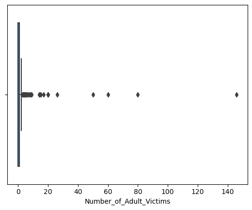

```python
sns.boxplot(x = hate_crime_stats['Number_of_Adult_Victims'])
```

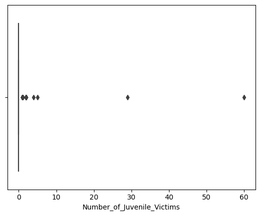

```python
sns.boxplot(x = hate_crime_stats['Number_of_Juvenile_Victims'])
```

**Human Readable Dataset.**

```python
# print out dataset after all transformations have been made

hate_crime_stats
```

|  | Incident_ID | Year | Originating_Agency_Identifier | Reporting_Agency_Name | Reporting_Agency_Unit | Reporting_Agency_Type | State_Abbreviation | State_Name | Specified_Region | Region_Name | ... | Offender_Race | Offender_Ethnicity | Number_of_Victims | Description_of_Hate_Crime | Total_Number_of_Victims | Location_of_Hate_Crime | Hate_Crime_Motivation | Description_of_Victims | Single_or_Multiple_Offense | Single_or_Multiple_Bias |
| --- | --- | --- | --- | --- | --- | --- | --- | --- | --- | --- | --- | --- | --- | --- | --- | --- | --- | --- | --- | --- | --- |
| 164544 | 164456 | 2013 | DE302SP00 | State Police: | New Castle County | State Police | DE | Delaware | South Atlantic | South | ... | Unknown | Unknown | 1 | Destruction/Damage/Vandalism of Property | 0.0 | Highway/Road/Alley/Street/Sidewalk | Anti-Hispanic or Latino | Business | S | S |
| 165653 | 165637 | 2013 | MI1301300 | State Police: | Calhoun County | State Police | MI | Michigan | East North Central | Midwest | ... | White | Unknown | 1 | Intimidation | 1.0 | Church/Synagogue/Temple/Mosque | Anti-Black or African American | Individual | S | S |
| 168744 | 168595 | 2013 | VTVSP1100 | State Police: | Royalton | State Police | VT | Vermont | New England | Northeast | ... | White | Unknown | 2 | All Other Larceny;Simple Assault | 2.0 | Highway/Road/Alley/Street/Sidewalk | Anti-Black or African American | Individual | M | S |
| 170648 | 170673 | 2014 | IL0100700 | University of Illinois: | Urbana | University or College | IL | Illinois | East North Central | Midwest | ... | White | Unknown | 3 | Aggravated Assault | 3.0 | Highway/Road/Alley/Street/Sidewalk | Anti-Islamic (Muslim) | Individual | S | S |
| 170659 | 170674 | 2014 | IL016AC9E | Northwestern University: | Chicago | University or College | IL | Illinois | East North Central | Midwest | ... | Unknown | Unknown | 1 | Not Specified | 1.0 | School-College/University | Anti-White | Individual | S | S |
| ... | ... | ... | ... | ... | ... | ... | ... | ... | ... | ... | ... | ... | ... | ... | ... | ... | ... | ... | ... | ... | ... |
| 219049 | 1349458 | 2020 | WVWSP4900 | State Police: | Sutton | State Police | WV | West Virginia | South Atlantic | South | ... | White | Unknown | 1 | Drug/Narcotic Violations | 0.0 | Highway/Road/Alley/Street/Sidewalk | Anti-Atheism/Agnosticism | Society/Public | S | S |
| 219050 | 1349505 | 2020 | WVWSP5100 | State Police: | Union | State Police | WV | West Virginia | South Atlantic | South | ... | White | Unknown | 1 | Motor Vehicle Theft | 1.0 | Residence/Home | Anti-Other Religion | Individual | S | S |
| 219051 | 1283297 | 2020 | WVWSP5200 | State Police: | Wayne | State Police | WV | West Virginia | South Atlantic | South | ... | White | Unknown | 1 | Simple Assault | 1.0 | Residence/Home | Anti-Black or African American | Individual | S | S |
| 219052 | 1283308 | 2020 | WVWSP5200 | State Police: | Wayne | State Police | WV | West Virginia | South Atlantic | South | ... | White | Unknown | 1 | All Other Larceny | 0.0 | Specialty Store | Anti-White | Business | S | S |
| 219053 | 1349506 | 2020 | WVWSP5200 | State Police: | Wayne | State Police | WV | West Virginia | South Atlantic | South | ... | White | Unknown | 1 | Drug/Narcotic Violations | 0.0 | Highway/Road/Alley/Street/Sidewalk | Anti-Hispanic or Latino | Society/Public | S | S |

899 rows × 28 columns

In order to clean up the hate crime dataset, the column names were changed to reflect names that were both easier to read and more descriptive of the content within them. The whitespace between column names was replaced with an underscore to align with Python conventions and best practices and increase readability and compatibility. The next steps look for both null values and duplicate values in the dataset. Finally, rows with null values were dropped from the dataset. It is important to ensure that the data we are using is obtained legally and provides accurate information about the crimes. The risk that could be created based on the transformations done is the removal of a row containing a null value that may include additional important values elsewhere. No assumptions were made in cleaning/transforming the data. The dataset was sourced from the Federal Bureau of Investigation - Crime Data Explorer, indicating its credibility and reliability. Given it originated from the FBI, we can confidently assert that the acquisition of this data was conducted ethically, adhering to legal and regulatory guidelines.

### *Project Milestone 3*

```python
# import required libraries
import pandas as pd
import numpy as np
import matplotlib.pyplot as plt
import seaborn as sns
from scipy import stats
import requests
from bs4 import BeautifulSoup
```

```python
# read the HTML file and extract tables
tables = pd.read_html('FBI — Table 5.html')
fbi_table = tables[0]

# display the DataFrame
fbi_table.head()
```

|  | State | Area | Unnamed: 2 | Population | Violent crime1 | Murder and nonnegligent manslaughter | Rape2 | Robbery | Aggravated assault | Property crime | Burglary | Larceny-theft | Motor vehicle theft |
| --- | --- | --- | --- | --- | --- | --- | --- | --- | --- | --- | --- | --- | --- |
| 0 | ALABAMA | Metropolitan Statistical Area | NaN | 3728978 | NaN | NaN | NaN | NaN | NaN | NaN | NaN | NaN | NaN |
| 1 | ALABAMA | Metropolitan Statistical Area | Area actually reporting | 76.6% | 12880.0 | 182.0 | 1141.0 | 1706.0 | 9851.0 | 65789.0 | 12388.0 | 47299.0 | 6102.0 |
| 2 | ALABAMA | Metropolitan Statistical Area | Estimated total | 100.0% | 19951.0 | 300.0 | 1542.0 | 3432.0 | 14677.0 | 104658.0 | 20728.0 | 73857.0 | 10073.0 |
| 3 | ALABAMA | Cities outside metropolitan areas | NaN | 528518 | NaN | NaN | NaN | NaN | NaN | NaN | NaN | NaN | NaN |
| 4 | ALABAMA | Cities outside metropolitan areas | Area actually reporting | 89.3% | 3327.0 | 36.0 | 297.0 | 266.0 | 2728.0 | 17915.0 | 3140.0 | 13382.0 | 1393.0 |

```python
# check size of dataframe
fbi_table.shape
```

```
(510, 13)
```

```python
# get data summary ie datatype, missing values, memory usage and structure
fbi_table.info()
```

```
<class 'pandas.core.frame.DataFrame'>
RangeIndex: 510 entries, 0 to 509
Data columns (total 13 columns):
 #   Column                                Non-Null Count  Dtype
---  ------                                --------------  -----
 0   State                                 510 non-null    object
 1   Area                                  510 non-null    object
 2   Unnamed: 2                            303 non-null    object
 3   Population                            447 non-null    object
 4   Violent crime1                        355 non-null    float64
 5   Murder and nonnegligent manslaughter  355 non-null    float64
 6   Rape2                                 355 non-null    float64
 7   Robbery                               355 non-null    float64
 8   Aggravated assault                    355 non-null    float64
 9   Property crime                        355 non-null    float64
 10  Burglary                              355 non-null    float64
 11  Larceny-theft                         355 non-null    float64
 12  Motor vehicle theft                   355 non-null    float64
dtypes: float64(9), object(4)
memory usage: 51.9+ KB
```

**Step 1: Rename Headers.**

```python
# rename the columns to make it more clean
fbi_table.rename(columns = {"State": "State", "Area": "Area", "Unnamed: 2": "Reporting or Total Population",
                            "Population": "Population", "Violent crime1": "Violent Crime",\
                            "Murder and nonnegligent manslaughter": "Murder and NonNegligent Manslaughter", "Rape2": "Rape", "Robbery": "Robbery", \
                            "Aggravated assault": "Aggravated Assault", "Property crime": "Property Crime", "Burglary": "Burglary",
                            "Larceny-theft": "Larceny-Theft", "Motor vehicle theft": "Motor Vehicle Theft"}, inplace = True)

fbi_table.head()
```

|  | State | Area | Reporting or Total Population | Population | Violent Crime | Murder and NonNegligent Manslaughter | Rape | Robbery | Aggravated Assault | Property Crime | Burglary | Larceny-Theft | Motor Vehicle Theft |
| --- | --- | --- | --- | --- | --- | --- | --- | --- | --- | --- | --- | --- | --- |
| 0 | ALABAMA | Metropolitan Statistical Area | NaN | 3728978 | NaN | NaN | NaN | NaN | NaN | NaN | NaN | NaN | NaN |
| 1 | ALABAMA | Metropolitan Statistical Area | Area actually reporting | 76.6% | 12880.0 | 182.0 | 1141.0 | 1706.0 | 9851.0 | 65789.0 | 12388.0 | 47299.0 | 6102.0 |
| 2 | ALABAMA | Metropolitan Statistical Area | Estimated total | 100.0% | 19951.0 | 300.0 | 1542.0 | 3432.0 | 14677.0 | 104658.0 | 20728.0 | 73857.0 | 10073.0 |
| 3 | ALABAMA | Cities outside metropolitan areas | NaN | 528518 | NaN | NaN | NaN | NaN | NaN | NaN | NaN | NaN | NaN |
| 4 | ALABAMA | Cities outside metropolitan areas | Area actually reporting | 89.3% | 3327.0 | 36.0 | 297.0 | 266.0 | 2728.0 | 17915.0 | 3140.0 | 13382.0 | 1393.0 |

In order to make the header names more uniform and easy to read, rename them to use the same casing all throughout as well as removing unneccessary numbers.

**Step 2: Replace White Spaces in Column Names with an Underscore.**

```python
# use snake_case instead of whitespace for column names to increase readability and compatibility
fbi_table.columns = fbi_table.columns.str.replace(' ','_')

# verifiy new column names
fbi_table.head()
```

|  | State | Area | Reporting_or_Total_Population | Population | Violent_Crime | Murder_and_NonNegligent_Manslaughter | Rape | Robbery | Aggravated_Assault | Property_Crime | Burglary | Larceny-Theft | Motor_Vehicle_Theft |
| --- | --- | --- | --- | --- | --- | --- | --- | --- | --- | --- | --- | --- | --- |
| 0 | ALABAMA | Metropolitan Statistical Area | NaN | 3728978 | NaN | NaN | NaN | NaN | NaN | NaN | NaN | NaN | NaN |
| 1 | ALABAMA | Metropolitan Statistical Area | Area actually reporting | 76.6% | 12880.0 | 182.0 | 1141.0 | 1706.0 | 9851.0 | 65789.0 | 12388.0 | 47299.0 | 6102.0 |
| 2 | ALABAMA | Metropolitan Statistical Area | Estimated total | 100.0% | 19951.0 | 300.0 | 1542.0 | 3432.0 | 14677.0 | 104658.0 | 20728.0 | 73857.0 | 10073.0 |
| 3 | ALABAMA | Cities outside metropolitan areas | NaN | 528518 | NaN | NaN | NaN | NaN | NaN | NaN | NaN | NaN | NaN |
| 4 | ALABAMA | Cities outside metropolitan areas | Area actually reporting | 89.3% | 3327.0 | 36.0 | 297.0 | 266.0 | 2728.0 | 17915.0 | 3140.0 | 13382.0 | 1393.0 |

This step transforms all the columns with whitespace between the names by replacing that whitespace with an underscore. This helps increase readability and aligns with Python best practices.

**Step 3: Check for Missing Values.**

```python
# get counts for null/NaN values
fbi_table.isna().sum()
```

```
State                                     0
Area                                      0
Reporting_or_Total_Population           207
Population                               63
Violent_Crime                           155
Murder_and_NonNegligent_Manslaughter    155
Rape                                    155
Robbery                                 155
Aggravated_Assault                      155
Property_Crime                          155
Burglary                                155
Larceny-Theft                           155
Motor_Vehicle_Theft                     155
dtype: int64
```

This step checks for the missing values and gives the count of missing values for each column.

**Step 4: Check for Duplicates.**

```python
# check to see if duplicates exist
fbi_table.duplicated().sum()
```

```
0
```

This step checks for any duplicates and gives the count (if any).

**Step 5: Fill in Missing Data.**

```python
# fill in missing data with 'NA'

fbi_table.fillna('NA', inplace = True)

fbi_table.head(10)
```

|  | State | Area | Reporting_or_Total_Population | Population | Violent_Crime | Murder_and_NonNegligent_Manslaughter | Rape | Robbery | Aggravated_Assault | Property_Crime | Burglary | Larceny-Theft | Motor_Vehicle_Theft |
| --- | --- | --- | --- | --- | --- | --- | --- | --- | --- | --- | --- | --- | --- |
| 0 | ALABAMA | Metropolitan Statistical Area | NA | 3728978 | NA | NA | NA | NA | NA | NA | NA | NA | NA |
| 1 | ALABAMA | Metropolitan Statistical Area | Area actually reporting | 76.6% | 12880.0 | 182.0 | 1141.0 | 1706.0 | 9851.0 | 65789.0 | 12388.0 | 47299.0 | 6102.0 |
| 2 | ALABAMA | Metropolitan Statistical Area | Estimated total | 100.0% | 19951.0 | 300.0 | 1542.0 | 3432.0 | 14677.0 | 104658.0 | 20728.0 | 73857.0 | 10073.0 |
| 3 | ALABAMA | Cities outside metropolitan areas | NA | 528518 | NA | NA | NA | NA | NA | NA | NA | NA | NA |
| 4 | ALABAMA | Cities outside metropolitan areas | Area actually reporting | 89.3% | 3327.0 | 36.0 | 297.0 | 266.0 | 2728.0 | 17915.0 | 3140.0 | 13382.0 | 1393.0 |
| 5 | ALABAMA | Cities outside metropolitan areas | Estimated total | 100.0% | 3541.0 | 37.0 | 310.0 | 301.0 | 2893.0 | 19177.0 | 3364.0 | 14305.0 | 1508.0 |
| 6 | ALABAMA | Nonmetropolitan counties | NA | 645689 | NA | NA | NA | NA | NA | NA | NA | NA | NA |
| 7 | ALABAMA | Nonmetropolitan counties | Area actually reporting | 72.4% | 874.0 | 13.0 | 148.0 | 55.0 | 658.0 | 4927.0 | 1387.0 | 2887.0 | 653.0 |
| 8 | ALABAMA | Nonmetropolitan counties | Estimated total | 100.0% | 1554.0 | 21.0 | 216.0 | 208.0 | 1109.0 | 7298.0 | 1987.0 | 4315.0 | 996.0 |
| 9 | ALABAMA | State Total | NA | 4903185 | 25046.0 | 358.0 | 2068.0 | 3941.0 | 18679.0 | 131133.0 | 26079.0 | 92477.0 | 12577.0 |

The NaN values that appeared in the table were cells where the data did not need to exist due to the way that the table is set up. In order to assist with confusion, adding NA for Not Applicable instead of leaving it as NaN.

**Step 6: Hierarchical Indexing.**

```python
# set hierarchical index by state and area
hierarchical_fbi_data = fbi_table.set_index(['State', 'Area'])
hierarchical_fbi_data.head()

hierarchical_fbi_data.tail()
```

| State | Area | Reporting_or_Total_Population | Population | Violent_Crime | Murder_and_NonNegligent_Manslaughter | Rape | Robbery | Aggravated_Assault | Property_Crime | Burglary | Larceny-Theft | Motor_Vehicle_Theft |
| --- | --- | --- | --- | --- | --- | --- | --- | --- | --- | --- | --- | --- |
| WYOMING | Nonmetropolitan counties | NA | 160615 | NA | NA | NA | NA | NA | NA | NA | NA | NA |
|  | Nonmetropolitan counties | Area actually reporting | 92.1% | 194.0 | 0.0 | 39.0 | 0.0 | 155.0 | 973.0 | 170.0 | 716.0 | 87.0 |
|  | Nonmetropolitan counties | Estimated total | 100.0% | 213.0 | 0.0 | 42.0 | 0.0 | 171.0 | 1065.0 | 188.0 | 781.0 | 96.0 |
|  | State Total | NA | 578759 | 1258.0 | 13.0 | 324.0 | 67.0 | 854.0 | 9093.0 | 1396.0 | 6984.0 | 713.0 |
|  | State Total | Rate per 100,000 inhabitants | NA | 217.4 | 2.2 | 56.0 | 11.6 | 147.6 | 1571.1 | 241.2 | 1206.7 | 123.2 |

Using hierarchical indexing allows the dataframe to look cleaner. It provides a structured way to organize and represent complex datasets like the one that is being used here.

**Human Readable Dataset.**

```python
# print out dataset after all transformations have been made
hierarchical_fbi_data
```

| State | Area | Reporting_or_Total_Population | Population | Violent_Crime | Murder_and_NonNegligent_Manslaughter | Rape | Robbery | Aggravated_Assault | Property_Crime | Burglary | Larceny-Theft | Motor_Vehicle_Theft |
| --- | --- | --- | --- | --- | --- | --- | --- | --- | --- | --- | --- | --- |
| ALABAMA | Metropolitan Statistical Area | NA | 3728978 | NA | NA | NA | NA | NA | NA | NA | NA | NA |
|  | Metropolitan Statistical Area | Area actually reporting | 76.6% | 12880.0 | 182.0 | 1141.0 | 1706.0 | 9851.0 | 65789.0 | 12388.0 | 47299.0 | 6102.0 |
|  | Metropolitan Statistical Area | Estimated total | 100.0% | 19951.0 | 300.0 | 1542.0 | 3432.0 | 14677.0 | 104658.0 | 20728.0 | 73857.0 | 10073.0 |
|  | Cities outside metropolitan areas | NA | 528518 | NA | NA | NA | NA | NA | NA | NA | NA | NA |
|  | Cities outside metropolitan areas | Area actually reporting | 89.3% | 3327.0 | 36.0 | 297.0 | 266.0 | 2728.0 | 17915.0 | 3140.0 | 13382.0 | 1393.0 |
| ... | ... | ... | ... | ... | ... | ... | ... | ... | ... | ... | ... | ... |
| WYOMING | Nonmetropolitan counties | NA | 160615 | NA | NA | NA | NA | NA | NA | NA | NA | NA |
|  | Nonmetropolitan counties | Area actually reporting | 92.1% | 194.0 | 0.0 | 39.0 | 0.0 | 155.0 | 973.0 | 170.0 | 716.0 | 87.0 |
|  | Nonmetropolitan counties | Estimated total | 100.0% | 213.0 | 0.0 | 42.0 | 0.0 | 171.0 | 1065.0 | 188.0 | 781.0 | 96.0 |
|  | State Total | NA | 578759 | 1258.0 | 13.0 | 324.0 | 67.0 | 854.0 | 9093.0 | 1396.0 | 6984.0 | 713.0 |
|  | State Total | Rate per 100,000 inhabitants | NA | 217.4 | 2.2 | 56.0 | 11.6 | 147.6 | 1571.1 | 241.2 | 1206.7 | 123.2 |

510 rows × 11 columns

In order to clean up the FBI’s Crime in the United States by State (2019) dataset, the column names were changed to remove numbers that were superscripted on some of the column titles as well as to name the unnamed column that existed. The whitespace between column names was replaced with an underscore to align with Python conventions and best practices and increase readability and compatibility. The next steps look for both null values and duplicate values in the dataset. Rows with null values were changed from NaN to NA since the cells were technically not empty but were cells that did not require input and were more so meant to be data-less. The final step was to create a hierarchical index that would provide a structured way to organize and represent the dataset, increase readability, and make it cleaner. It is important to ensure that the data we are using is obtained legally and provides accurate information about the crimes. I do not believe that there were any risks that may have been created based on the transformations done as the data was not changed other than the change from NaN to NA. No assumptions were made in cleaning/transforming the data. The dataset was sourced from the Federal Bureau of Investigation website through their Uniform Crime Reporting Program, indicating its credibility and reliability. Given it originated from the FBI, we can confidently assert that the acquisition of this data was conducted ethically, adhering to legal and regulatory guidelines.

### *Project Milestone 4*

```python
# import needed libraries
import requests
import json
import pandas as pd
```

```python
# connect to API
# base URL of the API
base_url = "https://api.usa.gov/crime/fbi/cde/"

# API key
api_key = "iiHnOKfno2Mgkt5AynpvPpUQTEyxE77jo1RU8PIv"
# variable to denote specific part of API being used
api_code = "hate-crime/national/offense/all?from=2019&to=2019"

# construct the API link with the API key as a query parameter
api_link = f"{base_url}{api_code}&api_key={api_key}"
print(api_link)

try:
    # send a GET request to the API
    response = requests.get(api_link)

    # check if the request was successful
    if response.status_code == 200:
        # print response data
        print("API Response:")
        print(response.json())
    else:
        # if the request was not successful, print error message
        print(f"Error: {response.status_code} - {response.reason}")
except requests.exceptions.RequestException as e:
    # handle connection errors or other exceptions
    print(f"An error occurred: {e}")
```

```
https://api.usa.gov/crime/fbi/cde/hate-crime/national/offense/all?from=2019&to=2019&api_key=iiHnOKfno2Mgkt5AynpvPpUQTEyxE77jo1RU8PIv
API Response:
{'keys': ['All Other Larceny', 'Aggravated Assault', 'Arson', 'Assisting or Promoting Prostitution', 'Betting/Wagering', 'Bribery', 'Burglary/Breaking & Entering', 'Counterfeiting/Forgery', 'Credit Card/Automated Teller Machine Fraud', 'Destruction/Damage/Vandalism of Property', 'Drug/Narcotic Viola…
```

```python
# parse the JSON data from the API response
json_data = response.json()

# normalize the JSON data to create a flat table
# 'data' is the key in the JSON response that contains the list of records
api_df = pd.json_normalize(json_data, ['data'])

# display the first 10 rows of the dataframe
api_df.head(10)
```

|  | data_year | bias | All Other Larceny | Aggravated Assault | Arson | Assisting or Promoting Prostitution | Betting/Wagering | Bribery | Burglary/Breaking & Entering | Counterfeiting/Forgery | ... | Explosives | Failure to Register as a Sex Offender | Illegal Entry into the United States | False Citizenship | Smuggling Aliens | Re-entry after Deportation | Espionage | Harboring Escapee/Concealing from Arrest | Flight to Avoid Prosecution | Flight to Avoid Deportation |
| --- | --- | --- | --- | --- | --- | --- | --- | --- | --- | --- | --- | --- | --- | --- | --- | --- | --- | --- | --- | --- | --- |
| 0 | 2019 | Anti-American Indian or Alaska Native | 14 | 3 | 2 | 0 | 0 | 0 | 4 | 0 | ... | 0 | 0 | 0 | 0 | 0 | 0 | 0 | 0 | 0 | 0 |
| 1 | 2019 | Anti-Arab | 1 | 19 | 0 | 0 | 0 | 0 | 1 | 0 | ... | 0 | 0 | 0 | 0 | 0 | 0 | 0 | 0 | 0 | 0 |
| 2 | 2019 | Anti-Asian | 2 | 33 | 2 | 0 | 0 | 0 | 3 | 1 | ... | 0 | 0 | 0 | 0 | 0 | 0 | 0 | 0 | 0 | 0 |
| 3 | 2019 | Anti-Atheism/Agnosticism | 1 | 0 | 0 | 0 | 0 | 0 | 0 | 0 | ... | 0 | 0 | 0 | 0 | 0 | 0 | 0 | 0 | 0 | 0 |
| 4 | 2019 | Anti-Bisexual | 0 | 4 | 0 | 0 | 0 | 0 | 1 | 0 | ... | 0 | 0 | 0 | 0 | 0 | 0 | 0 | 0 | 0 | 0 |
| 5 | 2019 | Anti-Black or African American | 9 | 364 | 14 | 0 | 0 | 0 | 19 | 0 | ... | 0 | 0 | 0 | 0 | 0 | 0 | 0 | 0 | 0 | 0 |
| 6 | 2019 | Anti-Buddhist | 2 | 0 | 0 | 0 | 0 | 0 | 0 | 0 | ... | 0 | 0 | 0 | 0 | 0 | 0 | 0 | 0 | 0 | 0 |
| 7 | 2019 | Anti-Catholic | 3 | 1 | 5 | 0 | 0 | 0 | 6 | 0 | ... | 0 | 0 | 0 | 0 | 0 | 0 | 0 | 0 | 0 | 0 |
| 8 | 2019 | Anti-Church of Jesus Christ | 0 | 3 | 0 | 0 | 0 | 0 | 0 | 0 | ... | 0 | 0 | 0 | 0 | 0 | 0 | 0 | 0 | 0 | 0 |
| 9 | 2019 | Anti-Eastern Orthodox (Russian, Greek, Other) | 9 | 2 | 0 | 0 | 0 | 0 | 5 | 0 | ... | 0 | 0 | 0 | 0 | 0 | 0 | 0 | 0 | 0 | 0 |

10 rows × 70 columns

```python
# check size of dataframe
api_df.shape
```

```
(34, 70)
```

```python
# get data summary ie datatype, missing values, memory usage and structure
api_df.info()
```

```
<class 'pandas.core.frame.DataFrame'>
RangeIndex: 34 entries, 0 to 33
Data columns (total 70 columns):
 #   Column                                       Non-Null Count  Dtype
---  ------                                       --------------  -----
 0   data_year                                    34 non-null     int64
 1   bias                                         34 non-null     object
 2   All Other Larceny                            34 non-null     int64
 3   Aggravated Assault                           34 non-null     int64
 4   Arson                                        34 non-null     int64
 5   Assisting or Promoting Prostitution          34 non-null     int64
 6   Betting/Wagering                             34 non-null     int64
 7   Bribery                                      34 non-null     int64
 8   Burglary/Breaking & Entering                 34 non-null     int64
 9   Counterfeiting/Forgery                       34 non-null     int64
```

[output cut: 62 more lines]

**Step 1: Rename Headers**

```python
# rename the first two columns to make it more clean
api_df.rename(columns = {"data_year": "Year", "bias": "Bias"}, inplace = True)

# verify new column names
api_df.head()
```

|  | Year | Bias | All Other Larceny | Aggravated Assault | Arson | Assisting or Promoting Prostitution | Betting/Wagering | Bribery | Burglary/Breaking & Entering | Counterfeiting/Forgery | ... | Explosives | Failure to Register as a Sex Offender | Illegal Entry into the United States | False Citizenship | Smuggling Aliens | Re-entry after Deportation | Espionage | Harboring Escapee/Concealing from Arrest | Flight to Avoid Prosecution | Flight to Avoid Deportation |
| --- | --- | --- | --- | --- | --- | --- | --- | --- | --- | --- | --- | --- | --- | --- | --- | --- | --- | --- | --- | --- | --- |
| 0 | 2019 | Anti-American Indian or Alaska Native | 14 | 3 | 2 | 0 | 0 | 0 | 4 | 0 | ... | 0 | 0 | 0 | 0 | 0 | 0 | 0 | 0 | 0 | 0 |
| 1 | 2019 | Anti-Arab | 1 | 19 | 0 | 0 | 0 | 0 | 1 | 0 | ... | 0 | 0 | 0 | 0 | 0 | 0 | 0 | 0 | 0 | 0 |
| 2 | 2019 | Anti-Asian | 2 | 33 | 2 | 0 | 0 | 0 | 3 | 1 | ... | 0 | 0 | 0 | 0 | 0 | 0 | 0 | 0 | 0 | 0 |
| 3 | 2019 | Anti-Atheism/Agnosticism | 1 | 0 | 0 | 0 | 0 | 0 | 0 | 0 | ... | 0 | 0 | 0 | 0 | 0 | 0 | 0 | 0 | 0 | 0 |
| 4 | 2019 | Anti-Bisexual | 0 | 4 | 0 | 0 | 0 | 0 | 1 | 0 | ... | 0 | 0 | 0 | 0 | 0 | 0 | 0 | 0 | 0 | 0 |

5 rows × 70 columns

The first two column names are missing capitalization on the first letter. In order to make everything uniform, we will correct this with proper capitalization as well as by correcting the data_year column to just reflect what is actually in it which is just the year.

**Step 2: Replace White Spaces in Column Names with an Underscore.**

```python
# use snake_case instead of whitespace for column names to increase readability and compatibility
api_df.columns = api_df.columns.str.replace(' ','_')

# verifiy new column names
api_df.head()
```

|  | Year | Bias | All_Other_Larceny | Aggravated_Assault | Arson | Assisting_or_Promoting_Prostitution | Betting/Wagering | Bribery | Burglary/Breaking_&_Entering | Counterfeiting/Forgery | ... | Explosives | Failure_to_Register_as_a_Sex_Offender | Illegal_Entry_into_the_United_States | False_Citizenship | Smuggling_Aliens | Re-entry_after_Deportation | Espionage | Harboring_Escapee/Concealing_from_Arrest | Flight_to_Avoid_Prosecution | Flight_to_Avoid_Deportation |
| --- | --- | --- | --- | --- | --- | --- | --- | --- | --- | --- | --- | --- | --- | --- | --- | --- | --- | --- | --- | --- | --- |
| 0 | 2019 | Anti-American Indian or Alaska Native | 14 | 3 | 2 | 0 | 0 | 0 | 4 | 0 | ... | 0 | 0 | 0 | 0 | 0 | 0 | 0 | 0 | 0 | 0 |
| 1 | 2019 | Anti-Arab | 1 | 19 | 0 | 0 | 0 | 0 | 1 | 0 | ... | 0 | 0 | 0 | 0 | 0 | 0 | 0 | 0 | 0 | 0 |
| 2 | 2019 | Anti-Asian | 2 | 33 | 2 | 0 | 0 | 0 | 3 | 1 | ... | 0 | 0 | 0 | 0 | 0 | 0 | 0 | 0 | 0 | 0 |
| 3 | 2019 | Anti-Atheism/Agnosticism | 1 | 0 | 0 | 0 | 0 | 0 | 0 | 0 | ... | 0 | 0 | 0 | 0 | 0 | 0 | 0 | 0 | 0 | 0 |
| 4 | 2019 | Anti-Bisexual | 0 | 4 | 0 | 0 | 0 | 0 | 1 | 0 | ... | 0 | 0 | 0 | 0 | 0 | 0 | 0 | 0 | 0 | 0 |

5 rows × 70 columns

This step transforms all the columns with whitespace between the names by replacing that whitespace with an underscore. This helps increase readability and aligns with Python best practices.

**Step 3: Check for Missing Values.**

```python
# get counts for null/NaN values
api_df.isna().sum()
```

```
Year                                        0
Bias                                        0
All_Other_Larceny                           0
Aggravated_Assault                          0
Arson                                       0
                                           ..
Re-entry_after_Deportation                  0
Espionage                                   0
Harboring_Escapee/Concealing_from_Arrest    0
Flight_to_Avoid_Prosecution                 0
Flight_to_Avoid_Deportation                 0
Length: 70, dtype: int64
```

This step checks for the missing values and gives the count of missing values for each column.

**Step 4: Check for Duplicates.**

```python
# check to see if duplicates exist

api_df.duplicated().sum()
```

```
0
```

This step checks for any duplicates and gives the count (if any).

**Step 5: Drop Redundant Column.**

```python
api_df.drop('Year', axis = 1, inplace = True)
api_df.head()
```

|  | Bias | All_Other_Larceny | Aggravated_Assault | Arson | Assisting_or_Promoting_Prostitution | Betting/Wagering | Bribery | Burglary/Breaking_&_Entering | Counterfeiting/Forgery | Credit_Card/Automated_Teller_Machine_Fraud | ... | Explosives | Failure_to_Register_as_a_Sex_Offender | Illegal_Entry_into_the_United_States | False_Citizenship | Smuggling_Aliens | Re-entry_after_Deportation | Espionage | Harboring_Escapee/Concealing_from_Arrest | Flight_to_Avoid_Prosecution | Flight_to_Avoid_Deportation |
| --- | --- | --- | --- | --- | --- | --- | --- | --- | --- | --- | --- | --- | --- | --- | --- | --- | --- | --- | --- | --- | --- |
| 0 | Anti-American Indian or Alaska Native | 14 | 3 | 2 | 0 | 0 | 0 | 4 | 0 | 0 | ... | 0 | 0 | 0 | 0 | 0 | 0 | 0 | 0 | 0 | 0 |
| 1 | Anti-Arab | 1 | 19 | 0 | 0 | 0 | 0 | 1 | 0 | 0 | ... | 0 | 0 | 0 | 0 | 0 | 0 | 0 | 0 | 0 | 0 |
| 2 | Anti-Asian | 2 | 33 | 2 | 0 | 0 | 0 | 3 | 1 | 0 | ... | 0 | 0 | 0 | 0 | 0 | 0 | 0 | 0 | 0 | 0 |
| 3 | Anti-Atheism/Agnosticism | 1 | 0 | 0 | 0 | 0 | 0 | 0 | 0 | 0 | ... | 0 | 0 | 0 | 0 | 0 | 0 | 0 | 0 | 0 | 0 |
| 4 | Anti-Bisexual | 0 | 4 | 0 | 0 | 0 | 0 | 1 | 0 | 0 | ... | 0 | 0 | 0 | 0 | 0 | 0 | 0 | 0 | 0 | 0 |

5 rows × 69 columns

This data was pulled specifically for the year 2019 and thus, this column is redundant in the data. We can remove this column as it is not needed.

**Step 6: Hierarchical Indexing.**

```python
# set hierarchical index by state and area
hierarchical_api_df = api_df.set_index(['Bias'])
hierarchical_api_df.head()
```

| Bias | All_Other_Larceny | Aggravated_Assault | Arson | Assisting_or_Promoting_Prostitution | Betting/Wagering | Bribery | Burglary/Breaking_&_Entering | Counterfeiting/Forgery | Credit_Card/Automated_Teller_Machine_Fraud | Destruction/Damage/Vandalism_of_Property | ... | Explosives | Failure_to_Register_as_a_Sex_Offender | Illegal_Entry_into_the_United_States | False_Citizenship | Smuggling_Aliens | Re-entry_after_Deportation | Espionage | Harboring_Escapee/Concealing_from_Arrest | Flight_to_Avoid_Prosecution | Flight_to_Avoid_Deportation |
| --- | --- | --- | --- | --- | --- | --- | --- | --- | --- | --- | --- | --- | --- | --- | --- | --- | --- | --- | --- | --- | --- |
| Anti-American Indian or Alaska Native | 14 | 3 | 2 | 0 | 0 | 0 | 4 | 0 | 0 | 15 | ... | 0 | 0 | 0 | 0 | 0 | 0 | 0 | 0 | 0 | 0 |
| Anti-Arab | 1 | 19 | 0 | 0 | 0 | 0 | 1 | 0 | 0 | 24 | ... | 0 | 0 | 0 | 0 | 0 | 0 | 0 | 0 | 0 | 0 |
| Anti-Asian | 2 | 33 | 2 | 0 | 0 | 0 | 3 | 1 | 0 | 29 | ... | 0 | 0 | 0 | 0 | 0 | 0 | 0 | 0 | 0 | 0 |
| Anti-Atheism/Agnosticism | 1 | 0 | 0 | 0 | 0 | 0 | 0 | 0 | 0 | 2 | ... | 0 | 0 | 0 | 0 | 0 | 0 | 0 | 0 | 0 | 0 |
| Anti-Bisexual | 0 | 4 | 0 | 0 | 0 | 0 | 1 | 0 | 0 | 4 | ... | 0 | 0 | 0 | 0 | 0 | 0 | 0 | 0 | 0 | 0 |

5 rows × 68 columns

Using hierarchical indexing allows the dataframe to look cleaner. It provides a structured way to organize and represent complex datasets like the one that is being used here. I specifically chose to do this because the indexing column bothered me and I felt that this made everything look prettier to the eyes.

**Human Readable Dataset.**

```python
# print out dataset after all transformations have been made

hierarchical_api_df.head(10)
```

| Bias | All_Other_Larceny | Aggravated_Assault | Arson | Assisting_or_Promoting_Prostitution | Betting/Wagering | Bribery | Burglary/Breaking_&_Entering | Counterfeiting/Forgery | Credit_Card/Automated_Teller_Machine_Fraud | Destruction/Damage/Vandalism_of_Property | ... | Explosives | Failure_to_Register_as_a_Sex_Offender | Illegal_Entry_into_the_United_States | False_Citizenship | Smuggling_Aliens | Re-entry_after_Deportation | Espionage | Harboring_Escapee/Concealing_from_Arrest | Flight_to_Avoid_Prosecution | Flight_to_Avoid_Deportation |
| --- | --- | --- | --- | --- | --- | --- | --- | --- | --- | --- | --- | --- | --- | --- | --- | --- | --- | --- | --- | --- | --- |
| Anti-American Indian or Alaska Native | 14 | 3 | 2 | 0 | 0 | 0 | 4 | 0 | 0 | 15 | ... | 0 | 0 | 0 | 0 | 0 | 0 | 0 | 0 | 0 | 0 |
| Anti-Arab | 1 | 19 | 0 | 0 | 0 | 0 | 1 | 0 | 0 | 24 | ... | 0 | 0 | 0 | 0 | 0 | 0 | 0 | 0 | 0 | 0 |
| Anti-Asian | 2 | 33 | 2 | 0 | 0 | 0 | 3 | 1 | 0 | 29 | ... | 0 | 0 | 0 | 0 | 0 | 0 | 0 | 0 | 0 | 0 |
| Anti-Atheism/Agnosticism | 1 | 0 | 0 | 0 | 0 | 0 | 0 | 0 | 0 | 2 | ... | 0 | 0 | 0 | 0 | 0 | 0 | 0 | 0 | 0 | 0 |
| Anti-Bisexual | 0 | 4 | 0 | 0 | 0 | 0 | 1 | 0 | 0 | 4 | ... | 0 | 0 | 0 | 0 | 0 | 0 | 0 | 0 | 0 | 0 |
| Anti-Black or African American | 9 | 364 | 14 | 0 | 0 | 0 | 19 | 0 | 1 | 593 | ... | 0 | 0 | 0 | 0 | 0 | 0 | 0 | 0 | 0 | 0 |
| Anti-Buddhist | 2 | 0 | 0 | 0 | 0 | 0 | 0 | 0 | 0 | 3 | ... | 0 | 0 | 0 | 0 | 0 | 0 | 0 | 0 | 0 | 0 |
| Anti-Catholic | 3 | 1 | 5 | 0 | 0 | 0 | 6 | 0 | 0 | 40 | ... | 0 | 0 | 0 | 0 | 0 | 0 | 0 | 0 | 0 | 0 |
| Anti-Church of Jesus Christ | 0 | 3 | 0 | 0 | 0 | 0 | 0 | 0 | 0 | 7 | ... | 0 | 0 | 0 | 0 | 0 | 0 | 0 | 0 | 0 | 0 |
| Anti-Eastern Orthodox (Russian, Greek, Other) | 9 | 2 | 0 | 0 | 0 | 0 | 5 | 0 | 0 | 7 | ... | 0 | 0 | 0 | 0 | 0 | 0 | 0 | 0 | 0 | 0 |

10 rows × 68 columns

In order to clean up the information pulled from the FBI Crime Data API, the first two column names were changed to follow the same capitalization rules that the rest of the column names had. The whitespace between column names was replaced with an underscore to align with Python conventions and best practices and increase readability and compatibility. The next steps look for both null values and duplicate values in the dataset. The ‘Year’ column was dropped from the dataset as it didn’t provide any pertinent information since all of the data was from the same year (2019). The final step was to create a hierarchical index that would provide a structured way to organize and represent the dataset, increase readability, and make it cleaner. It is important to ensure that the data we are using is obtained legally and provides accurate information about the crimes. I do not believe that there were any risks that may have been created based on the transformations done to the data. No assumptions were made in cleaning/transforming the data. The dataset was sourced from the Federal Bureau of Investigation - Crime Data Explorer – FBI Crime Data API, indicating its credibility and reliability. Given it originated from the FBI, we can confidently assert that the acquisition of this data was conducted ethically, adhering to legal and regulatory guidelines.

### *Project Milestone 5*

**Join of `hate_crime_stats` and `api_df`**

```python
import sqlite3

# create SQLite Database
conn = sqlite3.connect('crime.db')

# load datasets into SQLite Tables
hate_crime_stats.to_sql('hate_crime_stats', conn, if_exists = 'replace', index = False)
fbi_table.to_sql('fbi_table', conn, if_exists = 'replace', index = False)
api_df.to_sql('api_df', conn, if_exists = 'replace', index = False)

# join Tables in Python
query = """
    SELECT *
    FROM hate_crime_stats
    JOIN api_df ON hate_crime_stats.Hate_Crime_Motivation = api_df.Bias
"""
joined_df = pd.read_sql_query(query, conn)

# close connection
conn.close()
```

```python
joined_df
```

|  | Incident_ID | Year | Originating_Agency_Identifier | Reporting_Agency_Name | Reporting_Agency_Unit | Reporting_Agency_Type | State_Abbreviation | State_Name | Specified_Region | Region_Name | ... | Explosives | Failure_to_Register_as_a_Sex_Offender | Illegal_Entry_into_the_United_States | False_Citizenship | Smuggling_Aliens | Re-entry_after_Deportation | Espionage | Harboring_Escapee/Concealing_from_Arrest | Flight_to_Avoid_Prosecution | Flight_to_Avoid_Deportation |
| --- | --- | --- | --- | --- | --- | --- | --- | --- | --- | --- | --- | --- | --- | --- | --- | --- | --- | --- | --- | --- | --- |
| 0 | 164456 | 2013 | DE302SP00 | State Police: | New Castle County | State Police | DE | Delaware | South Atlantic | South | ... | 0 | 0 | 0 | 0 | 0 | 0 | 0 | 0 | 0 | 0 |
| 1 | 165637 | 2013 | MI1301300 | State Police: | Calhoun County | State Police | MI | Michigan | East North Central | Midwest | ... | 0 | 0 | 0 | 0 | 0 | 0 | 0 | 0 | 0 | 0 |
| 2 | 168595 | 2013 | VTVSP1100 | State Police: | Royalton | State Police | VT | Vermont | New England | Northeast | ... | 0 | 0 | 0 | 0 | 0 | 0 | 0 | 0 | 0 | 0 |
| 3 | 170673 | 2014 | IL0100700 | University of Illinois: | Urbana | University or College | IL | Illinois | East North Central | Midwest | ... | 0 | 0 | 0 | 0 | 0 | 0 | 0 | 0 | 0 | 0 |
| 4 | 170674 | 2014 | IL016AC9E | Northwestern University: | Chicago | University or College | IL | Illinois | East North Central | Midwest | ... | 0 | 0 | 0 | 0 | 0 | 0 | 0 | 0 | 0 | 0 |
| ... | ... | ... | ... | ... | ... | ... | ... | ... | ... | ... | ... | ... | ... | ... | ... | ... | ... | ... | ... | ... | ... |
| 869 | 1349458 | 2020 | WVWSP4900 | State Police: | Sutton | State Police | WV | West Virginia | South Atlantic | South | ... | 0 | 0 | 0 | 0 | 0 | 0 | 0 | 0 | 0 | 0 |
| 870 | 1349505 | 2020 | WVWSP5100 | State Police: | Union | State Police | WV | West Virginia | South Atlantic | South | ... | 0 | 0 | 0 | 0 | 0 | 0 | 0 | 0 | 0 | 0 |
| 871 | 1283297 | 2020 | WVWSP5200 | State Police: | Wayne | State Police | WV | West Virginia | South Atlantic | South | ... | 0 | 0 | 0 | 0 | 0 | 0 | 0 | 0 | 0 | 0 |
| 872 | 1283308 | 2020 | WVWSP5200 | State Police: | Wayne | State Police | WV | West Virginia | South Atlantic | South | ... | 0 | 0 | 0 | 0 | 0 | 0 | 0 | 0 | 0 | 0 |
| 873 | 1349506 | 2020 | WVWSP5200 | State Police: | Wayne | State Police | WV | West Virginia | South Atlantic | South | ... | 0 | 0 | 0 | 0 | 0 | 0 | 0 | 0 | 0 | 0 |

874 rows × 97 columns

```python
joined_df.shape
```

```
(874, 97)
```

```python
joined_df.isna().sum()
```

```
Incident_ID                                 0
Year                                        0
Originating_Agency_Identifier               0
Reporting_Agency_Name                       0
Reporting_Agency_Unit                       0
                                           ..
Re-entry_after_Deportation                  0
Espionage                                   0
Harboring_Escapee/Concealing_from_Arrest    0
Flight_to_Avoid_Prosecution                 0
Flight_to_Avoid_Deportation                 0
Length: 97, dtype: int64
```

```python
len(joined_df['Hate_Crime_Motivation'])
```

```
874
```

```python
print(joined_df['Hate_Crime_Motivation'])
```

```
0             Anti-Hispanic or Latino
1      Anti-Black or African American
2      Anti-Black or African American
3               Anti-Islamic (Muslim)
4                          Anti-White
                    ...
869          Anti-Atheism/Agnosticism
870               Anti-Other Religion
871    Anti-Black or African American
872                        Anti-White
873           Anti-Hispanic or Latino
Name: Hate_Crime_Motivation, Length: 874, dtype: object
```

```python
print(joined_df['Bias'])
```

```
0             Anti-Hispanic or Latino
1      Anti-Black or African American
2      Anti-Black or African American
3               Anti-Islamic (Muslim)
4                          Anti-White
                    ...
869          Anti-Atheism/Agnosticism
870               Anti-Other Religion
871    Anti-Black or African American
872                        Anti-White
873           Anti-Hispanic or Latino
Name: Bias, Length: 874, dtype: object
```

**Count of Occurrences in Bias Column**

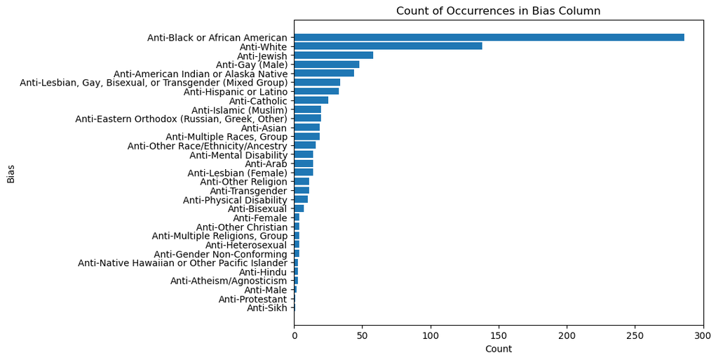

```python
# count occurrences of each category
category_counts = joined_df['Bias'].value_counts()

# reverse the order of the category counts
category_counts = category_counts[::-1]

# plotting a bar plot
plt.figure(figsize = (8, 6))
plt.barh(category_counts.index, category_counts.values)
plt.xlabel('Count')
# plt.xticks(rotation = 90)
plt.ylabel('Bias')
plt.title('Count of Occurrences in Bias Column')
plt.show()
```

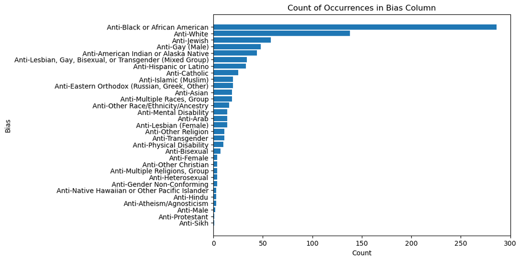

```python
# verifying that both bias and hate crime motivation columns return same results
# count occurrences of each category
category_counts = joined_df['Hate_Crime_Motivation'].value_counts()

# reverse the order of the category counts
category_counts = category_counts[::-1]

# plotting a bar plot
plt.figure(figsize = (8, 6))
plt.barh(category_counts.index, category_counts.values)
plt.xlabel('Count')
# plt.xticks(rotation = 90)
plt.ylabel('Bias')
plt.title('Count of Occurrences in Bias Column')
plt.show()
```

The aim here is to analyze the occurrences of different categories in the `Hate_Crime_Motivation`/`Bias` column of the joined dataset and visualize the results using a horizontal bar plot. Initially, the occurrences of each category are counted using the `value_counts()` function, providing insight into the frequency distribution of motivations behind hate crimes. The order of the category counts is then reversed to present the categories from the least to the most frequent. The resulting horizontal bar plot displays each category on the y-axis and its corresponding count on the x-axis, offering a clear visualization of the distribution of hate crime motivations. This visualization facilitates understanding of which motivations are most prevalent in the dataset, providing valuable insights into patterns and trends related to bias-motivated crimes. The visualization highlights a pronounced impact of hate crimes on individuals from the Black or African-American demographic.

**Join of `hate_crime_stats` and `fbi_table`**

```python
# create SQLite Database
conn = sqlite3.connect('crime.db')

# load datasets into SQLite Tables
hate_crime_stats.to_sql('hate_crime_stats', conn, if_exists = 'replace', index = False)
fbi_table.to_sql('fbi_table', conn, if_exists = 'replace', index = False)
api_df.to_sql('api_df', conn, if_exists = 'replace', index = False)

# join tables in Python

query = """
    SELECT *
    FROM hate_crime_stats
    JOIN fbi_table ON hate_crime_stats.State_Name COLLATE NOCASE = fbi_table.State COLLATE NOCASE
"""

joined_df2 = pd.read_sql_query(query, conn)

# close connection
conn.close()
```

```python
joined_df2
```

|  | Incident_ID | Year | Originating_Agency_Identifier | Reporting_Agency_Name | Reporting_Agency_Unit | Reporting_Agency_Type | State_Abbreviation | State_Name | Specified_Region | Region_Name | ... | Population | Violent_Crime | Murder_and_NonNegligent_Manslaughter | Rape | Robbery | Aggravated_Assault | Property_Crime | Burglary | Larceny-Theft | Motor_Vehicle_Theft |
| --- | --- | --- | --- | --- | --- | --- | --- | --- | --- | --- | --- | --- | --- | --- | --- | --- | --- | --- | --- | --- | --- |
| 0 | 164456 | 2013 | DE302SP00 | State Police: | New Castle County | State Police | DE | Delaware | South Atlantic | South | ... | NA | NA | NA | NA | NA | NA | NA | NA | NA | NA |
| 1 | 164456 | 2013 | DE302SP00 | State Police: | New Castle County | State Police | DE | Delaware | South Atlantic | South | ... | 100.0% | 4115.0 | 48.0 | 310.0 | 790.0 | 2967.0 | 21931.0 | 2968.0 | 17359.0 | 1604.0 |
| 2 | 164456 | 2013 | DE302SP00 | State Police: | New Castle County | State Police | DE | Delaware | South Atlantic | South | ... | 973764 | NA | NA | NA | NA | NA | NA | NA | NA | NA |
| 3 | 164456 | 2013 | DE302SP00 | State Police: | New Castle County | State Police | DE | Delaware | South Atlantic | South | ... | NA | NA | NA | NA | NA | NA | NA | NA | NA | NA |
| 4 | 164456 | 2013 | DE302SP00 | State Police: | New Castle County | State Police | DE | Delaware | South Atlantic | South | ... | 973764 | 4115.0 | 48.0 | 310.0 | 790.0 | 2967.0 | 21931.0 | 2968.0 | 17359.0 | 1604.0 |
| ... | ... | ... | ... | ... | ... | ... | ... | ... | ... | ... | ... | ... | ... | ... | ... | ... | ... | ... | ... | ... | ... |
| 6079 | 1349506 | 2020 | WVWSP5200 | State Police: | Wayne | State Police | WV | West Virginia | South Atlantic | South | ... | 83.1% | 908.0 | 15.0 | 119.0 | 21.0 | 753.0 | 2628.0 | 792.0 | 1495.0 | 341.0 |
| 6080 | 1349506 | 2020 | WVWSP5200 | State Police: | Wayne | State Police | WV | West Virginia | South Atlantic | South | ... | 100.0% | 1027.0 | 15.0 | 125.0 | 21.0 | 866.0 | 2784.0 | 858.0 | 1572.0 | 354.0 |
| 6081 | 1349506 | 2020 | WVWSP5200 | State Police: | Wayne | State Police | WV | West Virginia | South Atlantic | South | ... | 461358 | NA | NA | NA | NA | NA | NA | NA | NA | NA |
| 6082 | 1349506 | 2020 | WVWSP5200 | State Police: | Wayne | State Police | WV | West Virginia | South Atlantic | South | ... | 1792147 | 5674.0 | 78.0 | 754.0 | 378.0 | 4464.0 | 28376.0 | 5891.0 | 20066.0 | 2419.0 |
| 6083 | 1349506 | 2020 | WVWSP5200 | State Police: | Wayne | State Police | WV | West Virginia | South Atlantic | South | ... | NA | 316.6 | 4.4 | 42.1 | 21.1 | 249.1 | 1583.4 | 328.7 | 1119.7 | 135.0 |

6084 rows × 41 columns

**Count of Occurrences in State Column**

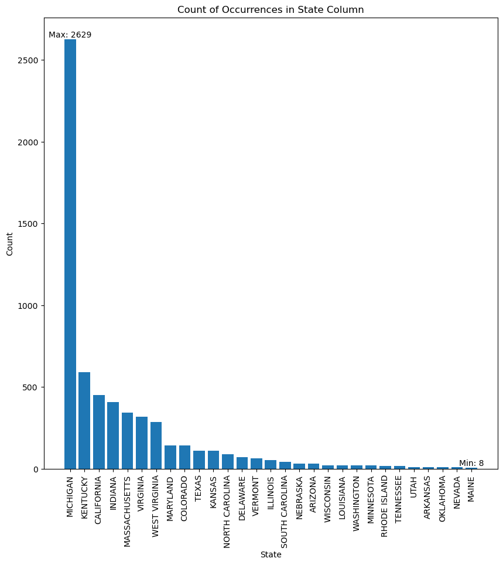

```python
# count occurrences of each category
category_counts2 = joined_df2['State'].value_counts()

# calculate the minimum and maximum values
min_value = category_counts2.min()
max_value = category_counts2.max()

# plot bar plot
plt.figure(figsize = (10, 10))
plt.bar(category_counts2.index, category_counts2.values)
plt.xlabel('State')
plt.xticks(rotation = 90)
plt.ylabel('Count')
plt.title('Count of Occurrences in State Column')

# annotate with minimum and maximum values
plt.text(category_counts2.idxmin(), min_value, f'Min: {min_value}', ha = 'center', va = 'bottom')
plt.text(category_counts2.idxmax(), max_value, f'Max: {max_value}', ha = 'center', va = 'bottom')

plt.show()
```

This computes the minimum and maximum values from the count of occurrences in the "State" column of the joined dataset and visualizes the distribution using a bar plot. The resulting plot provides insights into the frequency distribution of occurrences across different states. By annotating the bars with the minimum and maximum values, the visualization highlights the states with the lowest and highest occurrences, respectively. This additional information aids in understanding the range and distribution of occurrences across states, offering valuable insights for further analysis and interpretation.

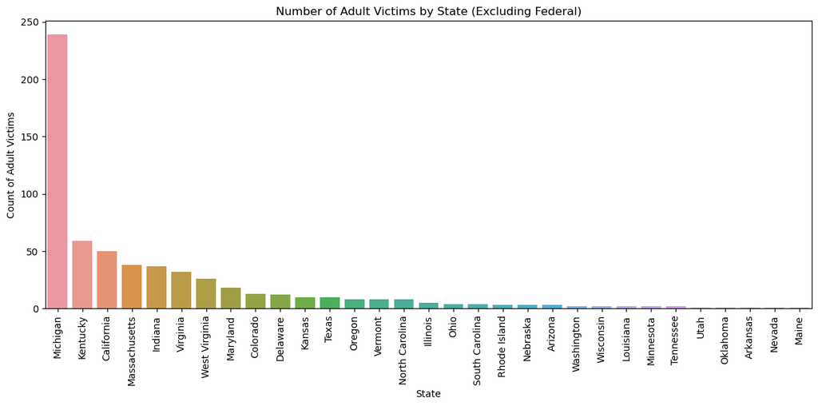

```python
import seaborn as sns

# filter out rows where the state is not 'Federal'
filtered_df = hate_crime_stats[hate_crime_stats['State_Name'] != 'Federal']

# plot a seaborn count plot
plt.figure(figsize = (12, 6))
sns.countplot(data = filtered_df, x = 'State_Name', order = filtered_df['State_Name'].value_counts().index)
plt.xlabel('State')
plt.ylabel('Count of Adult Victims')
plt.title('Number of Adult Victims by State (Excluding Federal)')
plt.xticks(rotation = 90)  # rotate x-axis labels for better readability
plt.tight_layout()  # adjust layout to prevent clipping of labels
plt.show()
```

**Relationship between Juvenile and Adult Victims by State**

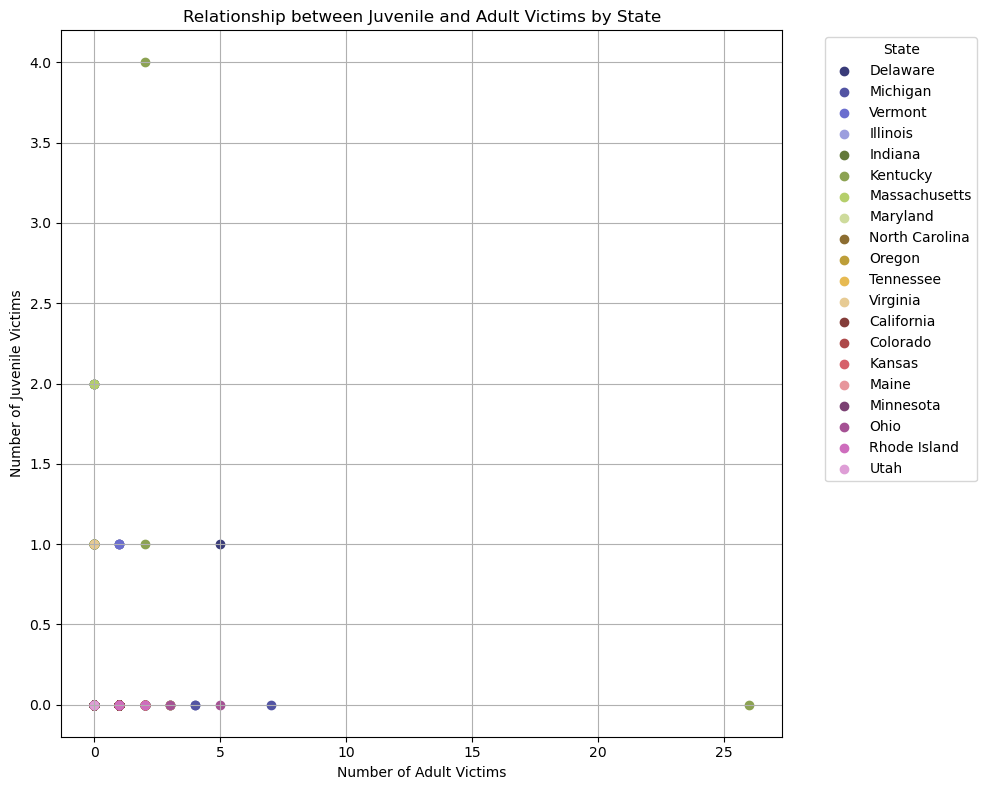

```python
# filter out rows where the state is not 'Federal'
filtered_df = hate_crime_stats[hate_crime_stats['State_Name'] != 'Federal']

# get unique states and assign a color to each state
unique_states = filtered_df['State_Name'].unique()
colors = plt.cm.tab20b.colors[:len(unique_states)]  # choose a color map and get colors for each state

# create a color dictionary mapping states to colors
color_dict = {state: color for state, color in zip(unique_states, colors)}

# plot a scatter plot with different colors for each state
plt.figure(figsize = (10, 8))
for state, color in color_dict.items():
    state_df = filtered_df[filtered_df['State_Name'] == state]
    plt.scatter(state_df['Number_of_Adult_Victims'], state_df['Number_of_Juvenile_Victims'], label = state, color = color)

plt.xlabel('Number of Adult Victims')
plt.ylabel('Number of Juvenile Victims')
plt.title('Relationship between Juvenile and Adult Victims by State')
plt.legend(title = 'State', bbox_to_anchor = (1.05, 1), loc = 'upper left')
plt.grid(True)  # add grid lines for better readability
plt.tight_layout()  # adjust layout to prevent clipping of labels
plt.show()
```

**Relationship between Bias and Intimidation**

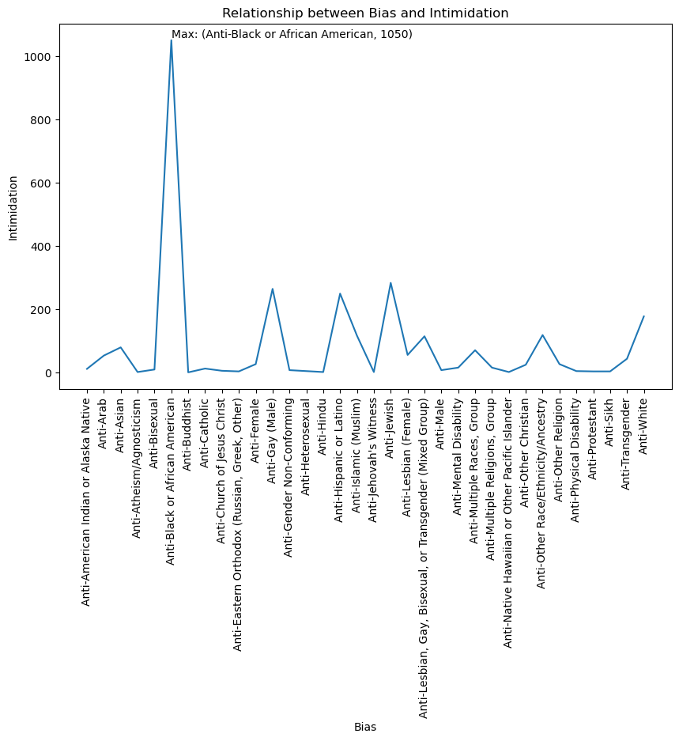

```python
# plot the relationship between 'Bias' and 'Intimidation' columns using a line plot
plt.figure(figsize = (10, 6))
sns.lineplot(data = api_df, x = 'Bias', y = 'Intimidation')
plt.title('Relationship between Bias and Intimidation')
plt.xlabel('Bias')
plt.xticks(rotation = 90)
plt.ylabel('Intimidation')

max_intimidation = api_df['Intimidation'].max()
max_bias = api_df.loc[api_df['Intimidation'].idxmax(), 'Bias']

plt.text(max_bias, max_intimidation, f'Max: ({max_bias}, {max_intimidation})', ha = 'left', va = 'bottom')

plt.show()
```

This part aims to visualize the relationship between the 'Bias' and 'Intimidation' columns of the dataset using a line plot. The resulting plot provides insights into the correlation between bias-motivated incidents and instances of intimidation. By plotting the 'Bias' values on the x-axis and 'Intimidation' values on the y-axis, the visualization depicts how changes in bias may influence the occurrence of intimidation incidents. Additionally, the plot includes an annotation indicating the maximum point on the line, denoting the highest level of intimidation observed in the dataset and its corresponding bias value. In this study, it's evident that the Black/African-American demographic remains the primary target of hate crimes, specifically in the form of intimidation as shown by the graphical analysis.

The final milestone aimed to join all three of the previously cleaned datasets into one dataset. Regrettably, my initial plan to join the datasets based on the State columns fell through due to limitations in accessing the API data in the desired format. Additionally, during Milestone 4, I erroneously assumed I could join the datasets based on offense types, which turned out to be unfeasible. To complete the assignment to the best of my abilities given the constraints, I decided to join only two tables on the bias associated with the crime. To fulfill the assignment requirements more comprehensively, I also opted to conduct an additional join operation in addition to the one previously mentioned. The second join merges the datasets "hate_crime_stats" and "fbi_table" based on the "State" column. It is important to ensure that the data we are using is obtained legally and provides accurate information about the crimes. I do not believe that there were any risks that may have been created based on the transformations done to the data. No assumptions were made in cleaning/transforming the data. The datasets were sourced from the Federal Bureau of Investigation - Crime Data Explorer , the Federal Bureau of Investigation website through their Uniform Crime Reporting Program, and the Federal Bureau of Investigation - Crime Data Explorer – FBI Crime Data API, indicating their credibility and reliability. Given that they all originated from the FBI, we can confidently assert that the acquisition of this data was conducted ethically, adhering to legal and regulatory guidelines.